# PuppiesXY (study2children)

Adam Stone, PhD

04-21-2018

# Let’s go! 26 Babies.

For now we’re just working with babies. So that means we need to pull baby info from `cleanedbabyeyedata.feather`. Below is a table of how many rows of data each baby has. I removed the first 60 data points from each trial (equivalent to 0.5 secs).

| name | n |
| --- | --- |
| AB11Mi20_5M_10D | 12453 |
| an06he01_6m | 3950 |
| aubrey CODA 11m | 4843 |
| ca05he16_6m | 6248 |
| CR03TA11_12M_29D | 1922 |
| de02wi15_12m_10d | 2926 |
| desmond | 29139 |
| DY10PE27_6m_11d_m | 14723 |
| farhad0327_12m | 4698 |
| GemmaF_11_4_13_CODA | 8731 |

[output cut: 16 more lines]

And let’s get means per trial per baby.

```r
data_stats <- data %>%
  group_by(name, age, language, condition, trial) %>%
  summarise(x = mean(x, na.rm=TRUE),
            y = mean(y, na.rm=TRUE))
data_stats
```

| name | age | language | condition | trial | x | y |
| --- | --- | --- | --- | --- | --- | --- |
| AB11Mi20_5M_10D | 4.80 | english | 02acd908-ea71-4012-b411-5033d69b53aa.jpg | 2 | 355.44444 | 251.37037 |
| AB11Mi20_5M_10D | 4.80 | english | 02acd908-ea71-4012-b411-5033d69b53aa.jpg | 10 | 379.65248 | 191.94326 |
| AB11Mi20_5M_10D | 4.80 | english | 1d699588-ff39-48fe-b02e-99332f1c3c74.JPG | 9 | 39.00000 | 125.00000 |
| AB11Mi20_5M_10D | 4.80 | english | 36a5dcda-b54b-48b9-a1cd-e9481f16f90b.jpg | 1 | 503.85981 | 298.29907 |
| AB11Mi20_5M_10D | 4.80 | english | 37c1fdb8-1269-436b-b472-861735cdeffe.jpg | 3 | 304.86207 | 298.32759 |
| AB11Mi20_5M_10D | 4.80 | english | 37c1fdb8-1269-436b-b472-861735cdeffe.jpg | 11 | 302.12174 | 176.68696 |
| AB11Mi20_5M_10D | 4.80 | english | a4a99b57-6b84-4a46-b3dc-5e2f9741ad91.jpg | 7 | 457.81786 | 259.82857 |
| AB11Mi20_5M_10D | 4.80 | english | a4a99b57-6b84-4a46-b3dc-5e2f9741ad91.jpg | 15 | 416.96552 | 215.03448 |
| AB11Mi20_5M_10D | 4.80 | english | bd5811eb-5a14-49bc-bc46-7146d626f56b.jpg | 6 | 301.71951 | 130.93902 |
| AB11Mi20_5M_10D | 4.80 | english | bd5811eb-5a14-49bc-bc46-7146d626f56b.jpg | 14 | 480.00000 | 104.00000 |

[output cut: 405 more lines]

Let’s visualize. Remember not all the puppy pictures are the same size, though.

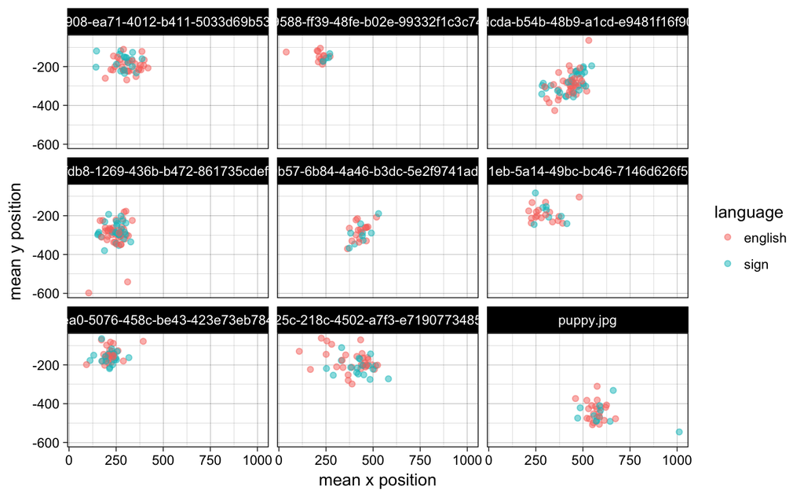

```r
ggplot(data_stats, aes(x = x, y = -1*y, color = language)) + geom_point(alpha = 0.5) + facet_wrap("condition") + theme_linedraw() + xlab("mean x position") + ylab("mean y position")
```

And run a linear mixed model. First, x-axis - no differences of group, age, or interactions. Great!

```r
lmm_x <- lmer(data = data_stats, x ~ language * age + (1|condition) + (1|name))
summary(lmm_x)
```

```
Linear mixed model fit by REML. t-tests use Satterthwaite's method ['lmerModLmerTest']
Formula: x ~ language * age + (1 | condition) + (1 | name)
   Data: data_stats

REML criterion at convergence: 4115.7

Scaled residuals:
    Min      1Q  Median      3Q     Max
-4.8492 -0.4198  0.0285  0.4733  6.6952

Random effects:
 Groups    Name        Variance Std.Dev.
 name      (Intercept)  1257     35.46
 condition (Intercept) 14870    121.94
 Residual               3356     57.93
Number of obs: 370, groups:  name, 26; condition, 9

Fixed effects:
                 Estimate Std. Error       df t value Pr(>|t|)
(Intercept)      341.0784    50.4869  16.9649   6.756  3.4e-06 ***
languagesign      42.2232    57.1539  22.1084   0.739    0.468
age                0.4803     3.4257  21.5830   0.140    0.890
languagesign:age  -3.4295     6.0615  21.8533  -0.566    0.577
---
Signif. codes:  0 ‘***’ 0.001 ‘**’ 0.01 ‘*’ 0.05 ‘.’ 0.1 ‘ ’ 1

Correlation of Fixed Effects:
            (Intr) lnggsg age
languagesgn -0.309
age         -0.561  0.495
langugsgn:g  0.316 -0.960 -0.565
```

Next, y-axis - no NSE/SE differences (p = 0.60) but there is an effect of age (p = 0.01)!! Interesting.

```r
lmm_y <- lmer(data = data_stats, y ~ language * age + (1|condition) + (1|name))
summary(lmm_y)
```

```
Linear mixed model fit by REML. t-tests use Satterthwaite's method ['lmerModLmerTest']
Formula: y ~ language * age + (1 | condition) + (1 | name)
   Data: data_stats

REML criterion at convergence: 3930

Scaled residuals:
    Min      1Q  Median      3Q     Max
-4.4459 -0.5102  0.0205  0.4671  6.1344

Random effects:
 Groups    Name        Variance Std.Dev.
 name      (Intercept)  473.7   21.77
 condition (Intercept) 8827.3   93.95
 Residual              2071.0   45.51
Number of obs: 370, groups:  name, 26; condition, 9

Fixed effects:
                 Estimate Std. Error      df t value Pr(>|t|)
(Intercept)       194.900     36.775  14.269   5.300 0.000105 ***
languagesign       19.317     36.848  22.313   0.524 0.605289
age                 5.605      2.202  21.534   2.545 0.018622 *
languagesign:age   -2.665      3.902  21.937  -0.683 0.501765
---
Signif. codes:  0 ‘***’ 0.001 ‘**’ 0.01 ‘*’ 0.05 ‘.’ 0.1 ‘ ’ 1

Correlation of Fixed Effects:
            (Intr) lnggsg age
languagesgn -0.271
age         -0.495  0.493
langugsgn:g  0.278 -0.960 -0.564
```

Let’s explore the effect of age on the y-axis some more…this tells us there IS an effect but it’s very subtle. And the LMM output above tells us that it’s about 5.6 pixels for every month. So a 12-month-old looks about 33 pixels lower compared to a 6-month-old. That is kind of nothing, it’s about half of an AOI. It’s a significant effect, but it’s maybe a tiny thing and likely nothing to worry about. I think!!

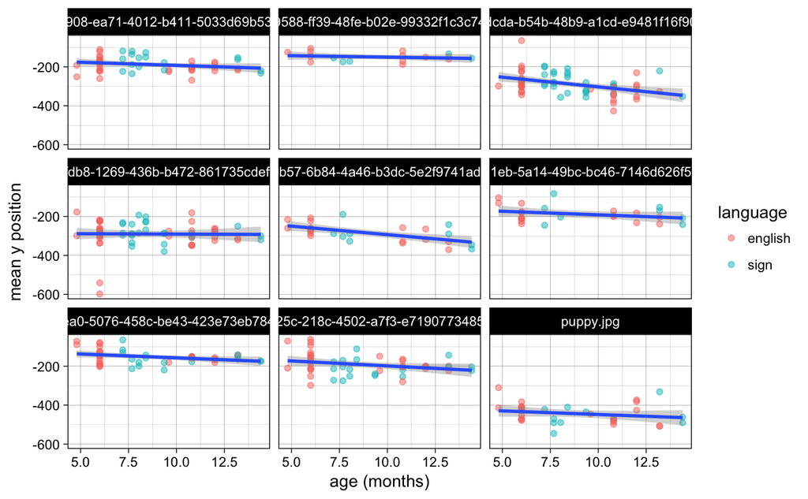

```r
ggplot(data_stats, aes(x = age, y = -1*y)) + geom_point(alpha = 0.5, aes(color = language)) + geom_smooth(method = "lm") + facet_wrap("condition") + theme_linedraw() + ylab("mean y position") +
  xlab("age (months)")
```

# Shifting 4 babies

How do results change if I shift 4 babies?

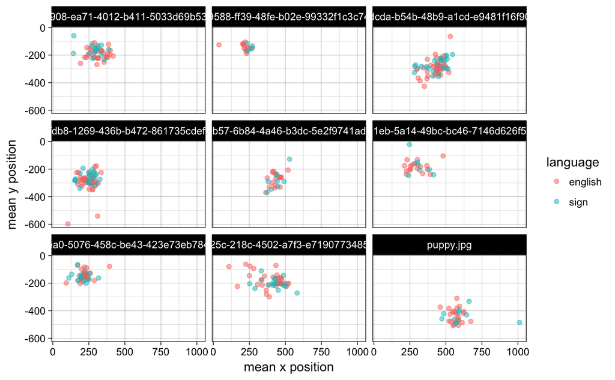

```r
data2 <- data_stats %>%
  mutate(y = case_when(
    name == "aubrey CODA 11m" ~ y-15,
    name == "LA11BA11_5M_24D" ~ y-50,
    name == "Parker 6 m SIGNING" ~ y-61,
    name == "Trinity 8m" ~ y-40,
    TRUE ~ y
  ))
ggplot(data2, aes(x = x, y = -1*y, color = language)) + geom_point(alpha = 0.5) + facet_wrap("condition") + theme_linedraw() + xlab("mean x position") + ylab("mean y position")
```

Now re-run the linear model for y-axis. The age effect is more significant (p = 0.003) and the magnitude is now 6.5 pixels per month. 12-month-olds look 39 pixels lower than 6-month-olds.

```r
lmm_y <- lmer(data = data2, y ~ language * age + (1|condition) + (1|name))
summary(lmm_y)
```

```
Linear mixed model fit by REML. t-tests use Satterthwaite's method ['lmerModLmerTest']
Formula: y ~ language * age + (1 | condition) + (1 | name)
   Data: data2

REML criterion at convergence: 3925.9

Scaled residuals:
    Min      1Q  Median      3Q     Max
-4.4417 -0.5130  0.0185  0.4804  6.2210

Random effects:
 Groups    Name        Variance Std.Dev.
 name      (Intercept)  366.5   19.14
 condition (Intercept) 8818.9   93.91
 Residual              2071.4   45.51
Number of obs: 370, groups:  name, 26; condition, 9

Fixed effects:
                 Estimate Std. Error      df t value Pr(>|t|)
(Intercept)       184.230     35.874  13.139   5.135 0.000185 ***
languagesign        4.175     33.528  22.214   0.125 0.902011
age                 6.485      2.000  21.283   3.243 0.003850 **
languagesign:age   -2.064      3.548  21.766  -0.582 0.566668
---
Signif. codes:  0 ‘***’ 0.001 ‘**’ 0.01 ‘*’ 0.05 ‘.’ 0.1 ‘ ’ 1

Correlation of Fixed Effects:
            (Intr) lnggsg age
languagesgn -0.252
age         -0.461  0.492
langugsgn:g  0.259 -0.960 -0.563
```

And the visualization.

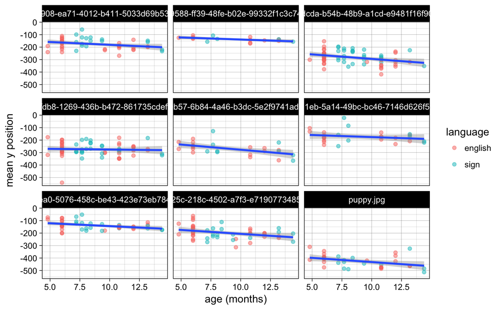

```r
ggplot(data2, aes(x = age, y = -1*y)) + geom_point(alpha = 0.5, aes(color = language)) + geom_smooth(method = "lm") + facet_wrap("condition") + theme_linedraw() + ylab("mean y position") +
  xlab("age (months)")
```